# FT Shooting Comparisons Part 1

Walter Mymala

8/9/2021

** Dataset from Jacob Baruch on Kaggle.com:https://www.kaggle.com/jacobbaruch/basketball-players-stats-per-season-49-leagues

Dataset Information:

Contains stats scraped from 49 basketball leagues from around the world from 1990 to 2020**

The purpose of this study is to see if the free throws are held to the highest standard in professional basketball between different years and different leagues. Free throws tend to be a genreal litmus test for one’s ability to be able to shoot the basketball in general. For example, it is known that people tend to look at NCAA players’s free throw percentage to judge their shooting potential for the professional game.

```r
# First row of the original dataset
head(D, n = 1L)
```

```
##   League      Season          Stage           Player Team GP  MIN FGM  FGA
## 1    NBA 1999 - 2000 Regular_Season Shaquille O'Neal  LAL 79 3163 956 1665
##       FGPct X3PM X3PA X3Pct FTM FTA     FTPct TOV  PF ORB DRB  REB AST STL BLK
## 1 0.5741742    0    1     0 432 824 0.5242718 223 255 336 742 1078 299  36 239
##    PTS  birth_date birth_year birth_month height height_cm weight weight_kg
## 1 2344 Mar 6, 1972       1972         Mar    7-1       216    325       147
##     nationality                 high_school draft_round draft_pick
## 1 United States Robert G. Cole High School            1          1
##      draft_team
## 1 Orlando Magic
```

```r
# All the available basketball leagues in the dataset
unique(D$League, incomparables = FALSE)
```

```
##  [1] "NBA"                                "Euroleague"
##  [3] "Eurocup"                            "Australian-NBL"
##  [5] "German-BBL"                         "Italian-Lega-Basket-Serie-A"
##  [7] "Spanish-ACB"                        "French-Jeep-Elite"
##  [9] "Argentinian-Liga-A"                 "Austrian-A-Bundesliga"
## [11] "Balkan-BIL"                         "Belarusian-BPL"
## [13] "Belgium-Scooore-League"             "Bosnian-BiH-Liga"
## [15] "Brazilian-NBB"                      "British-BBL"
## [17] "Bulgarian-NBL"                      "Canadian-NBL"
## [19] "Chinese-CBA"                        "Croatian-A-1-Liga"
## [21] "Czech-NBL"                          "Danish-Basketligaen"
## [23] "Finnish-Korisliiga"                 "Greek-HEBA-A1"
## [25] "Hungarian-NBIA"                     "Israeli-BSL"
## [27] "Lithuanian-LKL"                     "Macedonian-Superleague"
## [29] "Mexican-LNBP"                       "Netherlands-DBL"
## [31] "New-Zealand-NBL"                    "Norwegian-BLNO"
## [33] "Polish-TBL"                         "Romanian-Divizia-A"
## [35] "Serbian-KLS"                        "Slovakian-Extraliga"
## [37] "Slovenian-SKL"                      "South-Korean-KBL"
## [39] "Swedish-Basketligan"                "Swiss-LNA"
## [41] "Turkish-BSL"                        "Ukrainian-Superleague"
## [43] "Georgian-Super-Liga"                "Lebanese-Division-A"
## [45] "Luxembourg-Total-League"            "FIBA-Europe-Cup"
## [47] "Japanese-BLeague"                   "Kosovo-FBK"
## [49] "Estonian-Latvian-Basketball-League"
```

**Note: The Euroleague and Eurocup is comparable to soccer’s Champions League and Europa League in that it consists of having top European teams playing one another. These teams play in these respective leagues as well as their own domestic league concurrently. Essentially, there are some teams have are in the Euroleague and Eurocup while playing for their domestic league at the same time.**

** The European professional club basketball system starting in 2018**

From MrThirteenXIII from Reddit(https://www.reddit.com/r/Euroleague/comments/hiolt2/how_are_euroleague_teams_selected/): 13 teams have a contract {in the Euroleague} and they participate no matter what. These teams are Real Madrid(ESP), Barcelona(ESP), Baskonia(ESP), Olimpia Milano(ITA), Zalgiris(LTU), Panathinaikos(GRC), Olympiacos(GRC), Panathinaikos(GRC), Fenerbahce(TUR), Anadolu Efes(TUR), CSKA Moscow(RUS), LDLC ASVEL(FRA) and Maccabi Tel Aviv(ISR).

The 7 spots left :

• The winner of Eurocup (second tier European competition where 24 other teams participate)

• The winner of ABA league (league based on former countries of Yuguslavia: Bosnia and Herzegovina, Croatia, Macedonia, Montenegro, Serbia (including the regions of Kosovo and Vojvodina) and Slovenia)

• The winner or runner up of VTB(Russian) league (usually CSKA wins, so the second team from VTB)

• wildcard places lasting 2-years or 1-year

• The winner of BBL (German league).

I will now create a subset involving NBA and Euroleague data since they are the 2 subjectively best(in ability) basketball leagues. To limit outliers, only players that meet the statistical minimums to qualify for league leaders qualify in their respective subsets and merge them together.

```r
# subset from dataframe just the NBA in 2019-2020 regular season(RS) with statistical minimums to qualify for NBA League Leaders:
# observations drop from 360 to 125 after adding statistical minimum

NBA19_20R <- D %>% filter(League == "NBA", Season == "2019 - 2020", FTA >= 125)

# subset dataframe of Euroleague in the 2019-2020 RS with statistical minimums to qualify for leagues leaders(Euroleague players must play 51% of games to be in league leaders, so 34 • .51 = 17.34 is 18 games minimum)
# observations drop from 237 to 183 after adding statistical minimum

EuroL19_20R <- D %>% filter(League == "Euroleague", Season == "2019 - 2020", GP >= 18)

NBAxEuroL19_20R <- rbind(NBA19_20R, EuroL19_20R) # merge NBA & Euroleague data
```

I will then make a scatterplot in an attempt to compare FT% and 3PT% between the 2 leagues and see if there is anything worth mentioning.

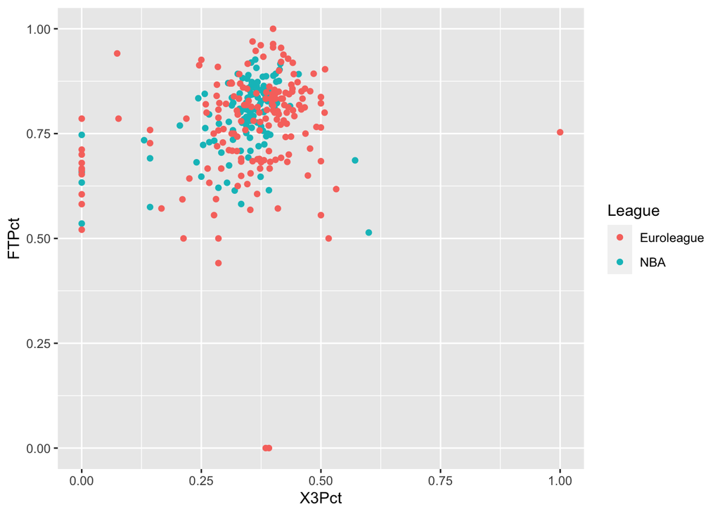

```r
# ggplot scatterplot
ggplot(NBAxEuroL19_20R, aes(x = X3Pct, y = FTPct, col = League)) + geom_point()
```

Using another scatterplot, I also want to represent points by mapping so the individual dots change depending on the PTS variable(Note: NBA plays more games than Euroleague). I also isolated NBA player Andre Drummond’s point on the data since he scores a lot of points but is a bad free throw shooter as well as bad 3 point shooter.

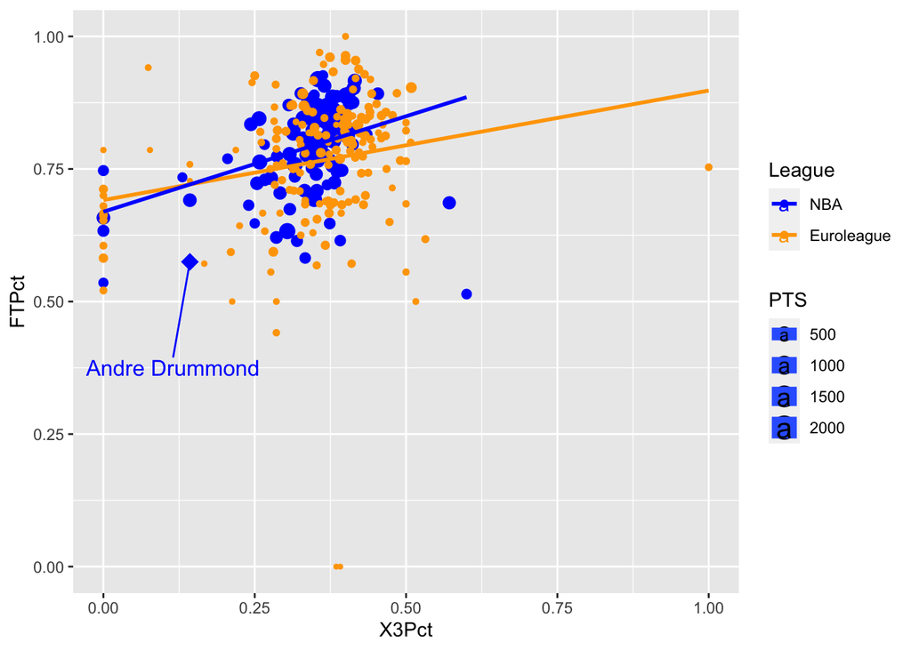

```r
plot <- ggplot(NBAxEuroL19_20R, aes(x = X3Pct, y = FTPct, col = League, size = PTS)) + geom_point(shape = ifelse(NBAxEuroL19_20R$Player == "Andre Drummond", 18, 20)) + scale_color_manual(values = c("NBA" = "blue", "Euroleague" = "orange")) + geom_smooth(method = lm, se = FALSE) +
  geom_text_repel(label = ifelse(NBAxEuroL19_20R$Player == "Andre Drummond", "Andre Drummond", ""), nudge_x = -.05,
    box.padding = 0.5,
    nudge_y = -0.2,
    segment.curvature = -0.1,
    segment.ncp = 3,
    segment.angle = 0)

plot
```

```r
cor(NBAxEuroL19_20R$X3Pct, NBAxEuroL19_20R$FTPct)
```

```
## [1] NA
```

In this part of the study, I want to compare free throw percentage between the NBA and Eurolegue in the 2019 - 2020 season by making separate charts for side-by side comparisons by making separate charts.

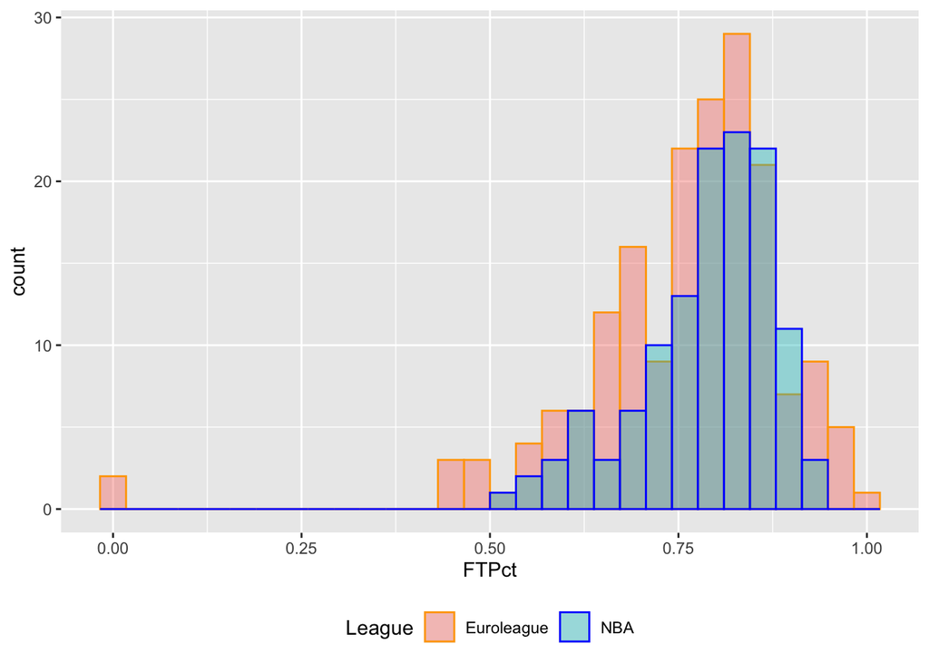

```r
# histogram - overlaid and separated by league

ggplot(NBAxEuroL19_20R, aes(x = FTPct, fill = League, color = League)) +
  geom_histogram(alpha = 0.4, position = "identity") + scale_color_manual(values=c("orange", "blue")) +
  theme(legend.position="bottom")
```

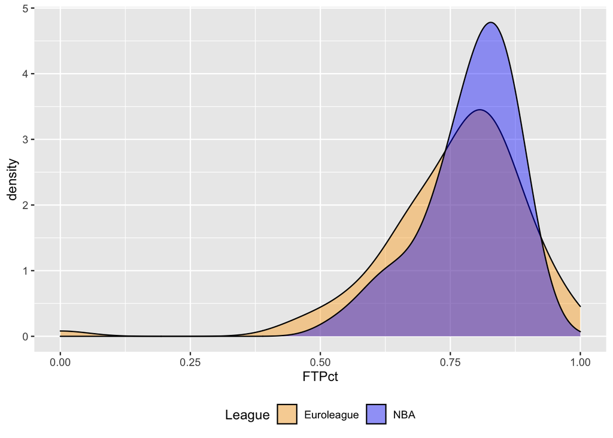

```r
# density chart
ggplot(data = NBAxEuroL19_20R, aes(x = FTPct, group = League, fill = League)) + geom_density(adjust = 1.5, alpha = .4) + scale_fill_manual(values=c("orange", "blue")) + theme(legend.position="bottom")
```

It seems like histograms along with it’s density plots are the best way to display comparisons for free throw shooting information between groups.

In this part of the study, I want to compare free throw percentage between eras in the NBA to see if there are any drastic changes since the way basketball has been played has changed from the past decades until now. I want to now compare just the NBA between eras by making summary tables and density charts for side-by side comparisons between the eras and seasons within them since comparing decade by decade isn’t very accurate. I used WinesburgOhio’s post on Reddit as reference to when certain eras are in the NBA. (https://www.reddit.com/r/nbadiscussion/comments/khl4zh/eras_in_nba_history_when_do_they_beginend_and_why/).

Eras(Summarized):

• ’93-’03: Jordan Era. Dead ball era—slower paced games and more defensive minded. 3 point shooting starting to be utilized more.

• ’04-’13: Kobe Era. Pace picked back up, 3 point shooting up more, more individual NBA talent than before.

• ’14-Present: Curry/3-point era. Pace increased, 3-point shooting increased considerably, positionless basketball, defense harder to play b/c refs(ticky-tack fouls), analytics to judge players.

Important rule changes that may affect free throw percentages(from https://www.deseret.com/2019/2/21/20666425/nba-rules-have-adapted-over-the-years-to-make-the-game-more-fun-for-players-fans):

• 2001 — “Illegal defense eliminated and zone defense allowed. Defensive 3-second rule prohibits defensive player from being in lane without guarding offensive player” (Sorenson, DeseretNews)

• 2018 — “Shot clock reset to 14 after an offensive rebound rather than 24” (Sorenson, DeseretNews)

I wanted to create summary table first to see if there were any major differences from a glance of the between the ranges of the 1st and 3rd quantiles. Note: “n = …” refers to players in the season that were recorded in the data.

```r
NBA <- D %>% filter(League == "NBA")
```

```
##
##
## +-----------------+-----------------+-----------------+-----------------+
## | 99-00 (n = 342) | 00-01 (n = 315) | 01-02 (n = 319) | 02-03 (n = 364) |
## +=================+=================+=================+=================+
## |  Min.  :0.0000  |  Min.  :0.0000  |  Min.  :0.0000  |  Min.  :0.2500  |
## +-----------------+-----------------+-----------------+-----------------+
## | 1st Qu.:0.7000  | 1st Qu.:0.7002  | 1st Qu.:0.6878  | 1st Qu.:0.7000  |
## +-----------------+-----------------+-----------------+-----------------+
## | Median :0.7650  | Median :0.7664  | Median :0.7614  | Median :0.7681  |
## +-----------------+-----------------+-----------------+-----------------+
## |  Mean :0.7462   |  Mean :0.7529   |  Mean :0.7440   |  Mean :0.7574   |
## +-----------------+-----------------+-----------------+-----------------+
## | 3rd Qu.:0.8235  | 3rd Qu.:0.8275  | 3rd Qu.:0.8191  | 3rd Qu.:0.8333  |
## +-----------------+-----------------+-----------------+-----------------+
## |  Max.  :1.0000  |  Max.  :1.0000  |  Max.  :1.0000  |  Max.  :1.0000  |
## +-----------------+-----------------+-----------------+-----------------+
##
## Table: Jordan Era('93-'03)
```

Seems like the average quartiles and average median for FT% are similar to each other through the years (1Q: ~0.697, Med: ~0.765, 3Q: ~0.826). Let’s see this data visually through a histogram and density chart.

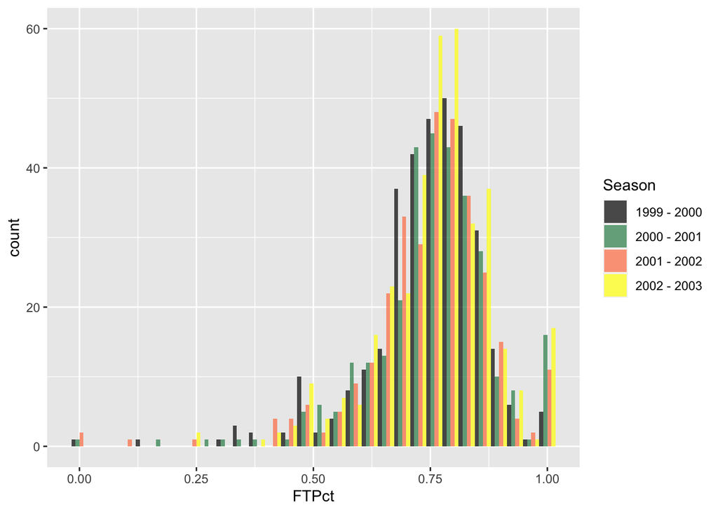

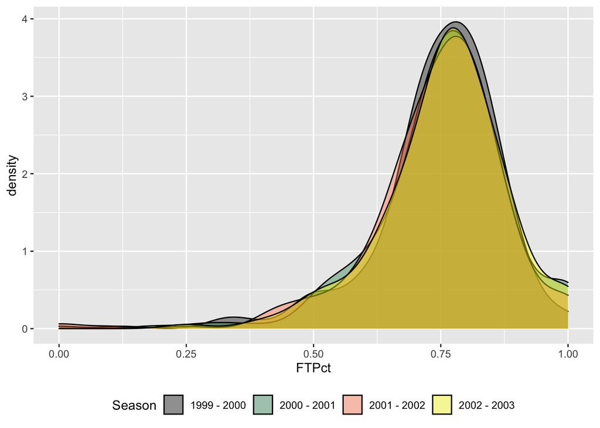

We can see that the distibution of each season in this era is around the sane with the center of the distributions concentated around 0.80 range.

Looking at the data, the Jordan Era with 4 seasons is way too much. I plan to stick with 3 seasons for each era and pick out which to choose depending on what values are on the summary table for each respective era. The histogram is very cluttered so I will stick to the density chartsince there will be more seasons for the other eras.

```
##
##
## +-----------------+-----------------+-----------------+-----------------+
## | 03-04 (n = 335) | 04-05 (n = 362) | 05-06 (n = 336) | 06-07 (n = 333) |
## +=================+=================+=================+=================+
## |  Min.  :0.1667  |  Min.  :0.0000  |  Min.  :0.0000  |  Min.  :0.2500  |
## +-----------------+-----------------+-----------------+-----------------+
## | 1st Qu.:0.6683  | 1st Qu.:0.6767  | 1st Qu.:0.6833  | 1st Qu.:0.6667  |
## +-----------------+-----------------+-----------------+-----------------+
## | Median :0.7579  | Median :0.7675  | Median :0.7619  | Median :0.7692  |
## +-----------------+-----------------+-----------------+-----------------+
## |  Mean :0.7389   |  Mean :0.7452   |  Mean :0.7449   |  Mean :0.7387   |
## +-----------------+-----------------+-----------------+-----------------+
## | 3rd Qu.:0.8182  | 3rd Qu.:0.8303  | 3rd Qu.:0.8263  | 3rd Qu.:0.8238  |
## +-----------------+-----------------+-----------------+-----------------+
## |  Max.  :1.0000  |  Max.  :1.0000  |  Max.  :1.0000  |  Max.  :1.0000  |
## +-----------------+-----------------+-----------------+-----------------+
##
## Table: Kobe Era('03-'13) (continued below)
##
##
##
## +-----------------+-----------------+-----------------+-----------------+
## | 07-08 (n = 362) | 08-09 (n = 352) | 09-10 (n = 349) | 10-11 (n = 339) |
## +=================+=================+=================+=================+
## |  Min.  :0.0000  |  Min.  :0.0000  |  Min.  :0.2500  |  Min.  :0.0000  |
## +-----------------+-----------------+-----------------+-----------------+
## | 1st Qu.:0.6850  | 1st Qu.:0.7062  | 1st Qu.:0.6949  | 1st Qu.:0.7066  |
## +-----------------+-----------------+-----------------+-----------------+
## | Median :0.7588  | Median :0.7816  | Median :0.7667  | Median :0.7706  |
## +-----------------+-----------------+-----------------+-----------------+
## |  Mean :0.7473   |  Mean :0.7632   |  Mean :0.7558   |  Mean :0.7569   |
## +-----------------+-----------------+-----------------+-----------------+
## | 3rd Qu.:0.8330  | 3rd Qu.:0.8394  | 3rd Qu.:0.8305  | 3rd Qu.:0.8333  |
## +-----------------+-----------------+-----------------+-----------------+
## |  Max.  :1.0000  |  Max.  :1.0000  |  Max.  :1.0000  |  Max.  :1.0000  |
## +-----------------+-----------------+-----------------+-----------------+
##
## Table: Table continues below
##
##
##
## +-----------------+-----------------+
## | 11-12 (n = 376) | 12-13 (n = 367) |
## +=================+=================+
## |  Min.  :0.0000  |  Min.  :0.2222  |
## +-----------------+-----------------+
## | 1st Qu.:0.6667  | 1st Qu.:0.6832  |
## +-----------------+-----------------+
## | Median :0.7619  | Median :0.7694  |
## +-----------------+-----------------+
## |  Mean :0.7316   |  Mean :0.7481   |
## +-----------------+-----------------+
## | 3rd Qu.:0.8207  | 3rd Qu.:0.8333  |
## +-----------------+-----------------+
## |  Max.  :1.0000  |  Max.  :1.0000  |
## +-----------------+-----------------+
```

The 1st quartile for this era is a little lower than the Jordan era however the median is around the same and 3rd quantile is higher. The differences are both insignificant though so we cannot say nything about FT% changing after comparing the eras.

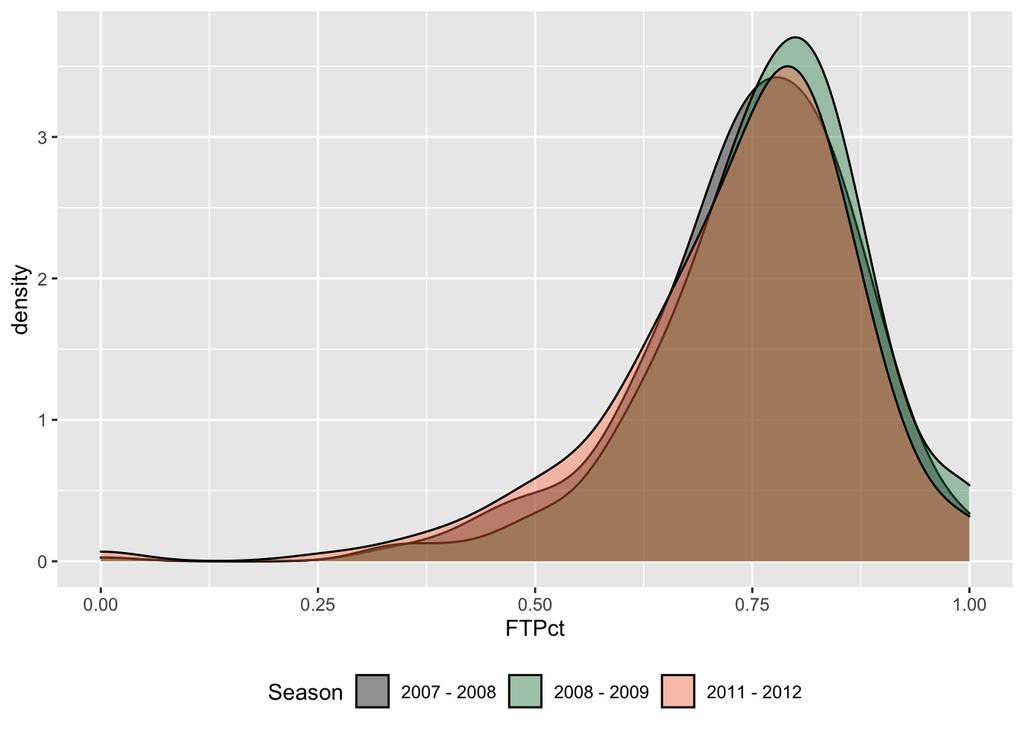

Other than the 08-09 season, the histogram distributions from this era look similar to the Jordan era’s. The 2011 - 2012 season is inflated because the season was shortened due to lockout but it turns out this didn’t affect the distribution for the season compared to the other seasons.

[output not shown]

We can say the distribution FT% in each era is around the same since the FT% averages between eras aren’t notically different. Note: the number of NBA players whose data was recorded seems to have taken a spike starting in the 16-17 season. Under 16-17 the reason is unknown but one reason for the spike starting from the 17-18 season, the NBA implemented extra roster places via 2-way contracts—player can play in NBA and G-league at same time. This should have affected our data by reducing the mean since 2-way contract players generally are young and not as good as their fully pro counterparts, but this case has turned out to be false. The data stayed the same.

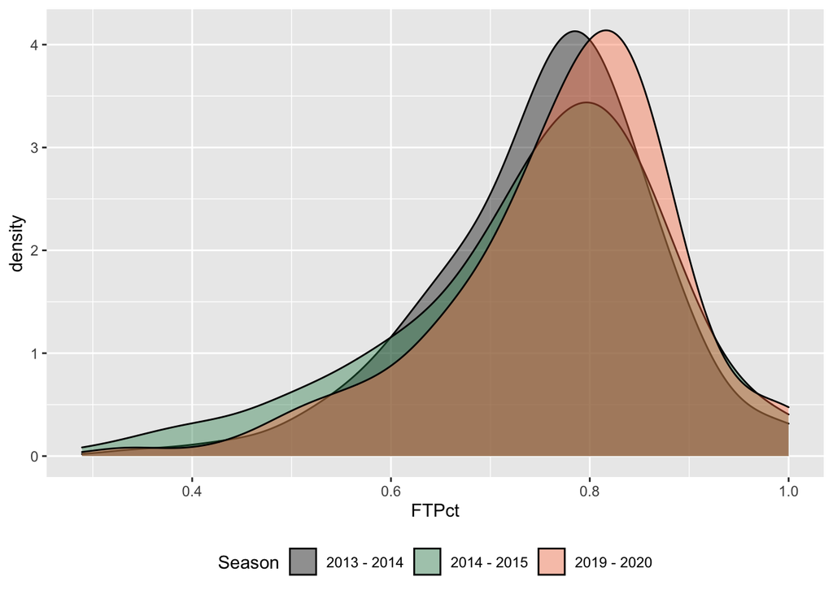

```r
# Seasons used were randomly chosen with R.
ModernEra = subset(NBA, Season == "2013 - 2014" | Season == "2014 - 2015" | Season == "2019 - 2020")

# Kobe Era density chart
ggplot(data = ModernEra, aes(x = FTPct, group = Season, fill = Season)) + geom_density(adjust = 1.5, alpha = .4) + scale_fill_manual(values=c("black", "seagreen", "coral")) + theme(legend.position="bottom")
```

Teams played 71–75 games(COVID) during the 2019-2020 season, the histogram distributions from this era look similar to the Jordan era’s. Other than the shortened season, the histogram distributions from this era look similar to the other 2 eras since center is condensed around the 75%-80% free throw range.

The data—table and density plot—for all the eras show that despite the change in play styles, change in pace, and more, the free throw percentage for NBA players has stayed pretty similar throughout. The lack of change in the statistic may indicate that free throws have continued to be a staple in most NBA players’s “bag”.

```
##
##
## +-----------------+-----------------+-----------------+
## | 04-05 (n = 362) | 11-12 (n = 376) | 17-18 (n = 430) |
## +=================+=================+=================+
## |  Min.  :0.0000  |  Min.  :0.0000  |  Min.  :0.0000  |
## +-----------------+-----------------+-----------------+
## | 1st Qu.:0.6767  | 1st Qu.:0.6667  | 1st Qu.:0.7000  |
## +-----------------+-----------------+-----------------+
## | Median :0.7675  | Median :0.7619  | Median :0.7746  |
## +-----------------+-----------------+-----------------+
## |  Mean :0.7452   |  Mean :0.7316   |  Mean :0.7586   |
## +-----------------+-----------------+-----------------+
## | 3rd Qu.:0.8303  | 3rd Qu.:0.8207  | 3rd Qu.:0.8402  |
## +-----------------+-----------------+-----------------+
## |  Max.  :1.0000  |  Max.  :1.0000  |  Max.  :1.0000  |
## +-----------------+-----------------+-----------------+
##
## Table: Era Comparison
```

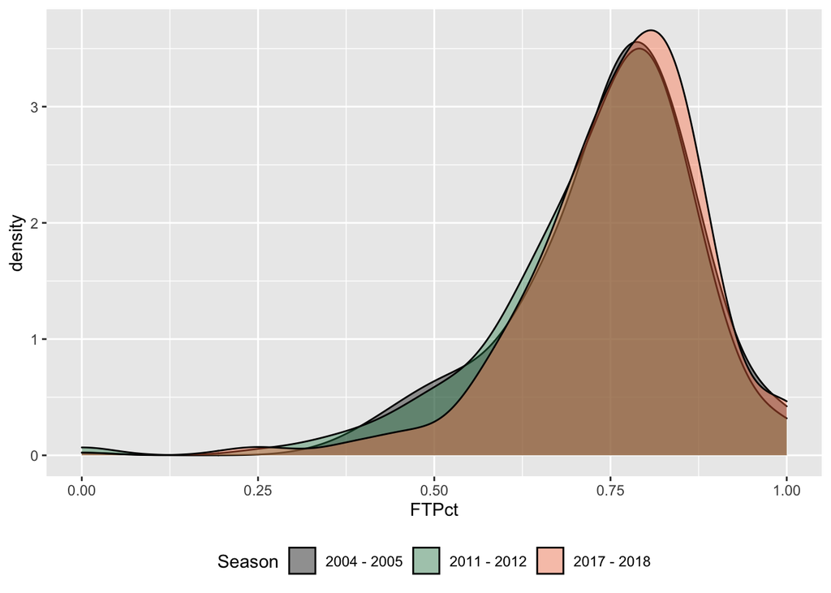

The 2017-2018 NBA season has a slightly higher mean then the higher seasons but the distrutions for all 3 seasons seem similar. The claim still holds that free throws have not changed for NBA players in terms of value/importance since FT% has not changed much despite the unique playstyles of each era. Based on the data comparisons, there is consistency concerning free throws and the percentage of players being able to hit them despite the evolution of the game throughout the years.

_____________________________________________________

**APPENDIX**

____________________________________________________

R Code used listed below.

```r
library(tidyverse)
library(dplyr)
library(ggplot2)
library(knitr)
library(ggrepel)

D <- read.csv("~/Desktop/MoneyBall/players_stats_by_season_full_details.csv")

D$FGPct = D$FGM / D$FGA # include FG% in dataset and order it in column neatly
D$FTPct = D$FTM / D$FTA # include FT% ...
D$X3Pct = D$X3PM / D$X3PA # include X3P% ...

# I manually add in new variables to dataset in order that I want instead of the end. There's got to be a better way to do this...
D = D %>% select(League, Season, Stage, Player, Team, GP, MIN, FGM, FGA, FGPct, X3PM, X3PA, X3Pct, FTM, FTA, FTPct, TOV, PF, ORB, DRB, REB, AST, STL, BLK, PTS, birth_date, birth_year, birth_month, height, height_cm, weight, weight_kg, nationality, high_school,  draft_round, draft_pick, draft_team)
# First row of the original dataset
head(D, n = 1L)
# All the available basketball leagues in the dataset
unique(D$League, incomparables = FALSE)

# subset from dataframe just the NBA in 2019-2020 regular season(RS) with statistical minimums to qualify for NBA League Leaders:
# observations drop from 360 to 125 after adding statistical minimum

NBA19_20R <- D %>% filter(League == "NBA", Season == "2019 - 2020", FTA >= 125)

# subset dataframe of Euroleague in the 2019-2020 RS with statistical minimums to qualify for leagues leaders(Euroleague players must play 51% of games to be in league leaders, so 34 • .51 = 17.34 is 18 games minimum)
# observations drop from 237 to 183 after adding statistical minimum

EuroL19_20R <- D %>% filter(League == "Euroleague", Season == "2019 - 2020", GP >= 18)

NBAxEuroL19_20R <- rbind(NBA19_20R, EuroL19_20R) # merge NBA & Euroleague data

# scatterplot w/o using ggplot for correlation btw 3P% (dependant) and FT% (independent)
plot(NBA19_20R$FTPct, NBA19_20R$X3Pct, xlab = 'Free Throw %', ylab = '3 point %')
# ggplot scatterplot
ggplot(NBAxEuroL19_20R, aes(x = X3Pct, y = FTPct, col = League)) + geom_point()
plot <- ggplot(NBAxEuroL19_20R, aes(x = X3Pct, y = FTPct, col = League, size = PTS)) + geom_point(shape = ifelse(NBAxEuroL19_20R$Player == "Andre Drummond", 18, 20)) + scale_color_manual(values = c("NBA" = "blue", "Euroleague" = "orange")) + geom_smooth(method = lm, se = FALSE) +
  geom_text_repel(label = ifelse(NBAxEuroL19_20R$Player == "Andre Drummond", "Andre Drummond", ""), nudge_x = -.05,
    box.padding = 0.5,
    nudge_y = -0.2,
    segment.curvature = -0.1,
    segment.ncp = 3,
    segment.angle = 0)

plot
cor(NBAxEuroL19_20R$X3Pct, NBAxEuroL19_20R$FTPct)
## ggplot practice
# map FTPct to transparency of each point
ggplot(NBAxEuroL19_20R) + geom_point(aes(x = X3Pct, y = FTPct, col = League, size = PTS, shape = League, alpha = FTPct)) + scale_color_manual(values = c("NBA" = "blue", "Euroleague" = "orange"))

ggplot(NBAxEuroL19_20R, aes(x = FTPct)) +
geom_histogram(bins = 30) + geom_histogram(color="black", fill="white")
# histogram - overlaid and separated by league

ggplot(NBAxEuroL19_20R, aes(x = FTPct, fill = League, color = League)) +
  geom_histogram(alpha = 0.4, position = "identity") + scale_color_manual(values=c("orange", "blue")) +
  theme(legend.position="bottom")

# density chart
ggplot(data = NBAxEuroL19_20R, aes(x = FTPct, group = League, fill = League)) + geom_density(adjust = 1.5, alpha = .4) + scale_fill_manual(values=c("orange", "blue")) + theme(legend.position="bottom")

NBA <- D %>% filter(League == "NBA")
# count how many datapoints for each one season(Jordan era)
D %>% filter(League == "NBA", Season == "1999 - 2000") %>% count # 342
D %>% filter(League == "NBA", Season == "2000 - 2001") %>% count # 315
D %>% filter(League == "NBA", Season == "2001 - 2002") %>% count # 319
D %>% filter(League == "NBA", Season == "2002 - 2003") %>% count # 364
Yr99_00 <- NBA %>% filter(Season == "1999 - 2000") %>% select(FTPct) %>% summary()
Yr00_01 <- NBA %>% filter(Season == "2000 - 2001") %>% select(FTPct) %>% summary()
Yr01_02 <- NBA %>% filter(Season == "2001 - 2002") %>% select(FTPct) %>% summary()
Yr02_03 <- NBA %>% filter(Season == "2002 - 2003") %>% select(FTPct) %>% summary()

JordanEraData <- data.frame(Yr99_00[1:6], Yr00_01[1:6], Yr01_02[1:6], Yr02_03[1:6])
colnames(JordanEraData) <- c("99-00 (n = 342)", "00-01 (n = 315)", "01-02 (n = 319)", "02-03 (n = 364)")

require(pander)
pandoc.table(JordanEraData, style = 'grid', caption = "Jordan Era('93-'03)")
JordanEra = subset(NBA, Season == "1999 - 2000" | Season == "2000 - 2001" | Season == "2001 - 2002" | Season == "2002 - 2003")

# Jordan Era histogram
ggplot(JordanEra, aes(x = FTPct, fill = Season)) + geom_histogram(alpha = 0.7, position = "dodge") + scale_fill_manual(labels = c("1999 - 2000", "2000 - 2001","2001 - 2002","2002 - 2003"), values=c("black", "seagreen", "coral", "yellow"))
  theme(legend.position="bottom")

# Jordan Era density chart
ggplot(data = JordanEra, aes(x = FTPct, group = Season, fill = Season)) + geom_density(adjust = 1.5, alpha = .4) + scale_fill_manual(values=c("black", "seagreen", "coral", "yellow")) + theme(legend.position="bottom")
# count how many datapoints for each one season (KB era)
D %>% filter(League == "NBA", Season == "2003 - 2004") %>% count # 335
D %>% filter(League == "NBA", Season == "2004 - 2005") %>% count # 362
D %>% filter(League == "NBA", Season == "2005 - 2006") %>% count # 336
D %>% filter(League == "NBA", Season == "2006 - 2007") %>% count # 333
D %>% filter(League == "NBA", Season == "2007 - 2008") %>% count # 362
D %>% filter(League == "NBA", Season == "2008 - 2009") %>% count # 352
D %>% filter(League == "NBA", Season == "2009 - 2010") %>% count # 349
D %>% filter(League == "NBA", Season == "2010 - 2011") %>% count # 339
D %>% filter(League == "NBA", Season == "2011 - 2012") %>% count # 376
D %>% filter(League == "NBA", Season == "2012 - 2013") %>% count # 367
Yr03_04 <- NBA %>% filter(Season == "2003 - 2004") %>% select(FTPct) %>% summary()
Yr04_05 <- NBA %>% filter(Season == "2004 - 2005") %>% select(FTPct) %>% summary()
Yr05_06 <- NBA %>% filter(Season == "2005 - 2006") %>% select(FTPct) %>% summary()
Yr06_07 <- NBA %>% filter(Season == "2006 - 2007") %>% select(FTPct) %>% summary()
Yr07_08 <- NBA %>% filter(Season == "2007 - 2008") %>% select(FTPct) %>% summary()
Yr08_09 <- NBA %>% filter(Season == "2008 - 2009") %>% select(FTPct) %>% summary()
Yr09_10 <- NBA %>% filter(Season == "2009 - 2010") %>% select(FTPct) %>% summary()
Yr10_11 <- NBA %>% filter(Season == "2010 - 2011") %>% select(FTPct) %>% summary()
Yr11_12 <- NBA %>% filter(Season == "2011 - 2012") %>% select(FTPct) %>% summary()
Yr12_13 <- NBA %>% filter(Season == "2012 - 2013") %>% select(FTPct) %>% summary()

KBData <- data.frame(Yr03_04[1:6], Yr04_05[1:6], Yr05_06[1:6], Yr06_07[1:6], Yr07_08[1:6], Yr08_09[1:6], Yr09_10[1:6], Yr10_11[1:6],Yr11_12[1:6], Yr12_13[1:6])
colnames(KBData) <- c("03-04 (n = 335)", "04-05 (n = 362)", "05-06 (n = 336)", "06-07 (n = 333)","07-08 (n = 362)", "08-09 (n = 352)", "09-10 (n = 349)", "10-11 (n = 339)", "11-12 (n = 376)", "12-13 (n = 367)")

require(pander)
pandoc.table(KBData, style = 'grid', caption = "Kobe Era('03-'13)")
# Seasons used were randomly chosen with R.
KBEra = subset(NBA, Season == "2007 - 2008" | Season == "2008 - 2009" | Season == "2011 - 2012")

# Kobe era density chart
ggplot(data = KBEra, aes(x = FTPct, group = Season, fill = Season)) + geom_density(adjust = 1.5, alpha = .4) + scale_fill_manual(values=c("black", "seagreen", "coral")) + theme(legend.position="bottom")
# count how many datapoints for each one season(3-point era)
D %>% filter(League == "NBA", Season == "2013 - 2014") %>% count # 361
D %>% filter(League == "NBA", Season == "2014 - 2015") %>% count # 346
D %>% filter(League == "NBA", Season == "2015 - 2016") %>% count # 350
D %>% filter(League == "NBA", Season == "2016 - 2017") %>% count # 440
D %>% filter(League == "NBA", Season == "2017 - 2018") %>% count # 430
D %>% filter(League == "NBA", Season == "2018 - 2019") %>% count # 435
D %>% filter(League == "NBA", Season == "2019 - 2020") %>% count # 420
Yr13_14 <- NBA %>% filter(Season == "2013 - 2014") %>% select(FTPct) %>% summary()
Yr14_15 <- NBA %>% filter(Season == "2014 - 2015") %>% select(FTPct) %>% summary()
Yr15_16 <- NBA %>% filter(Season == "2015 - 2016") %>% select(FTPct) %>% summary()
Yr16_17 <- NBA %>% filter(Season == "2016 - 2017") %>% select(FTPct) %>% summary()
Yr17_18 <- NBA %>% filter(Season == "2017 - 2018") %>% select(FTPct) %>% summary()
Yr18_19 <- NBA %>% filter(Season == "2018 - 2019") %>% select(FTPct) %>% summary()
Yr19_20 <- NBA %>% filter(Season == "2019 - 2020") %>% select(FTPct) %>% summary()

Currydata <- data.frame(Yr13_14[1:6], Yr14_15[1:6], Yr15_16[1:6], Yr16_17[1:6], Yr17_18[1:6], Yr18_19[1:6], Yr19_20[1:6])
colnames(Currydata) <- c("13-14 (n = 361)", "14-15 (n = 346)", "15-16 (n = 350)", "16-17 (n = 440)", "17-18 (n = 430)", "18-19 (n = 435)", "19-20 (n = 420)")

require(pander)
pandoc.table(Currydata, style = 'grid', caption = "3-point era('03-'13)")
# Seasons used were randomly chosen with R.
ModernEra = subset(NBA, Season == "2013 - 2014" | Season == "2014 - 2015" | Season == "2019 - 2020")

# Kobe Era density chart
ggplot(data = ModernEra, aes(x = FTPct, group = Season, fill = Season)) + geom_density(adjust = 1.5, alpha = .4) + scale_fill_manual(values=c("black", "seagreen", "coral")) + theme(legend.position="bottom")
# using sample() to randomize I got these seasons for respective era: 2, 9, 5
EraComparison <- data.frame(Yr04_05[1:6], Yr11_12[1:6], Yr17_18[1:6])

EraCompData <- data.frame(Yr04_05[1:6], Yr11_12[1:6], Yr17_18[1:6])
colnames(EraCompData) <- c("04-05 (n = 362)", "11-12 (n = 376)", "17-18 (n = 430)")

require(pander)
pandoc.table(EraCompData, style = 'grid', caption = "Era Comparison")
# Seasons used were randomly chosen with R.
EraComp = subset(NBA, Season == "2004 - 2005" | Season == "2011 - 2012" | Season == "2017 - 2018")

# Era density chart
ggplot(data = EraComp, aes(x = FTPct, group = Season, fill = Season)) + geom_density(adjust = 1.5, alpha = .4) + scale_fill_manual(values=c("black", "seagreen", "coral")) + theme(legend.position="bottom")
```